# Workshop on Causal Inference

Chicago Chapter of the American Statistical Association

April 18, 2019

## Introduction

- Recognize what to control for in DAGs
- Estimation methods
- Steps to causal inference
  - Define causal effects
  - Specify models
  - Specify and defend assumptions

## Causal effects and confounding

### Causal effects

#### *A*: treatment

- exposure/intervention of interest
- Random variable
- lowercase *a* refers to a realization of var *A*
- Treatment status of subject *i*

#### *Y*: outcome

- Could be continuous
- Could be time to event
- Could be multidimensional

#### Potential outcomes

- Y<sup>a</sup> for continuous ind var
- Y<sup>1</sup> and Y<sup>0</sup> for binary
  - i.e. Y<sup>1</sup>: time until individual would get flu if they received the vaccine
  - Y<sup>0</sup>: time until the individual would get the flu if they did not receive the vaccine

#### Observed outcomes

- Observed outcome *Y* is the outcome under treatment a subject received, i.e. *Y* = *Y*<sup>A</sup>
- Missing data problem where selection decided by treatment received

#### Independence

- Assuming that the treatment given to one subject does not affect outcome for another subject

#### Causal effects

- A had causal effect on *Y* if *Y*<sup>1</sup> =/= *Y*<sup>0</sup>
- Cant assume causal effect of ibuprofen without knowing untreated effect
- However can make estimates on population level (average causal effects)
- *E*(*Y*<sup>1</sup> - *Y*<sup>0</sup>)
  - Average outcome if everyone had been treated versus if everyone had been treated
  - Typically not equal to E(*Y*|A = 1) - E(*Y*|A = 0) (two subpopulations) unless we randomize
  - Pearl uses notation E(*Y*|*do*(*A* = 1)) - E(*Y*|*do*(A = 0))
  - *do* notation means “set” treatment, equal to notation on top

#### Other causal effects

- Potential risk ratio
- Causal effect of a subpopulation *E*(*Y*<sup>1</sup> - *Y*<sup>0</sup>|*V* = *v*)
- Removing an exposure, hypothetical “what ifs” E(*Y*<sup>1</sup> - *Y*<sup>0</sup> |A = 1)
- Quantile causal effects *F*<sub>$\overline{1}$</sub><sup>1</sup>(*p*) - *F*<sub>$\overline{0}$</sub><sup>1</sup>(*p*)

#### Valid examples

- Invalid when comparing same treatment on two separate groups without strong assuptions
- Not valid when comparing separate subpopulations even when we have different treatment effects

### Confounding

- When there are variables that affect the treatment decision and outcome
  - Also possible in randomized trials when there is noncompliance
  - Creates a problem because there is a lack of comparability between groups

#### Example

- Severe injury is affecting likelihood of getting surgery but its not deterministic
- Treatment will bump up *Y*<sup>a</sup>
- Will have separate distributions for *a*=0 and *a*=1, but curve might get pulled in one direction by *L*

#### Types of confounding

- Controllable confounding
- No confounding
- Confounding not controllable using standard methods but controllable using others (e.g. instrumental variables)
  - COuld use a natural randomizer
  - Difference of differences tries to difference out unmeasured confounding variables
- Uncontrollable confounding
  - Can do sensitivity analysis

#### Controllable confounding

- *L* is set of baseline (pre-treatment) covariates
- If we control for confounding we can assume any other differnces are random
- Controllable if there is overt (not hidden) bias
  - *f*(*Y*<sup>0</sup>, *Y*<sup>1</sup> |*L*,*A*) = *f*(*Y*<sup>0</sup>, *Y*<sup>1</sup> |*L*)
  - f(*A*|*L*, *Y*<sup>0</sup>, *Y*<sup>1</sup>) = f(*A*|*L*)

### Graphical Models

- dag terminology
  - Nodes are variables and paths are flow from one variable to another

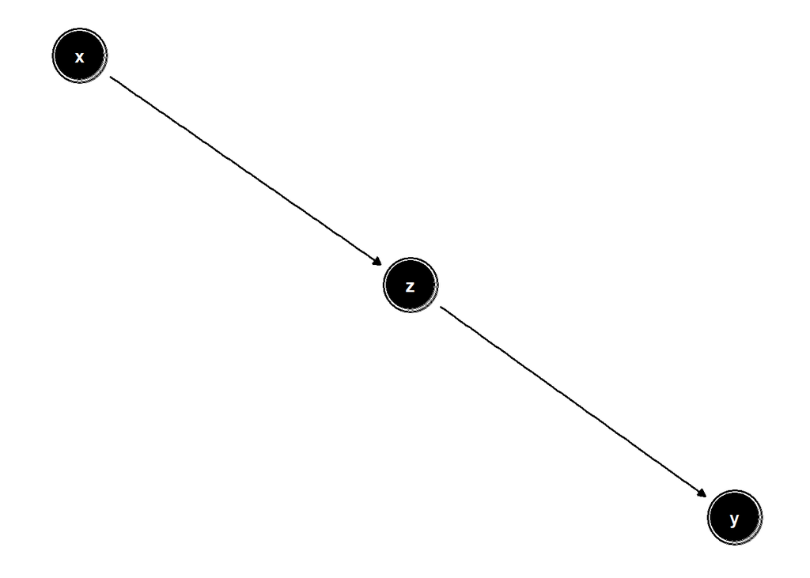

```r
library(dagitty)
library(ggdag)

dagified <- dagify(z ~ x,
                   y  ~ z,
                   exposure = "x",
                   outcome = "y")
dag <- tidy_dagitty(dagified)

ggdag(dag, layout = circle) +
  theme(panel.background = element_blank(), panel.grid.major = element_blank(), panel.grid.minor = element_blank())
```

- In this DAG:
  - X is parent of Z, ancestor of Y
  - Y is child of Z, descendent of X
  - This is an example of chains

#### Paths that do not induce association

- In cases of a *collider* G
  - A $\rightarrow$ G $\leftarrow$ B
  - A and B both affect G
  - A and B are both independent

#### Blocking

- Paths can be *blocked* by conditioning on nodes in the path
- Stopping the independence
- i.e. temperature -> icy sidewalks -> slipping
- We can block the relationship between temperature and slipping by conditioning on sidewalks

#### D-separation

A path is d-separated by a set of nodes C if:

- it contains a chain (D$\rightarrow$E$\rightarrow$F) and the middle part is in C

  OR
- it contains a fork (D$\leftarrow$E$\rightarrow$F) and the middle part is in C

  OR
- it contains an inverted form (D$\rightarrow$E$\leftarrow$F) and the middle part is not in C

#### Backdoor paths

*Backdoor paths* from treatment A to outcome Y are paths from A to that travel through arrows going into A

- These confound the relationship between A and Y
- Need to be blocked to make causal assumptions about effect of A on Y

#### Backdoor path criterion

Set of variables L is sufficient to control for confounding if:

- It blocks all backdoor paths from treatment to the outcome
- It does not include any descendants of treatment

This is the *backdoor path criterion*

- Can identify backdoor paths as those that go against the flow of information

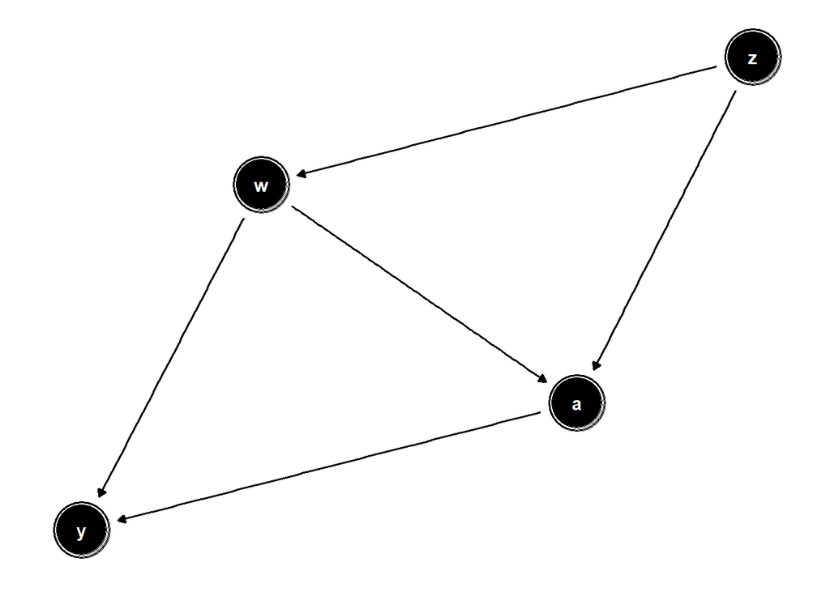

```r
dagified <- dagify(y ~ a,
                   a  ~ w,
                   y ~ w,
                   w ~ z,
                   a ~ z,
                   exposure = "a",
                   outcome = "y")
dag <- tidy_dagitty(dagified)

ggdag(dag, layout = circle) +
  theme(panel.background = element_blank(), panel.grid.major = element_blank(), panel.grid.minor = element_blank())
```

In this example we can block the backdoor path of information from a to y by controlling for W or for W and Z

- Can also control for other risk factors affecting y for sake of efficiency gains, does not affect causal outcome
- Conditioning on collider opens path between vars leading into collider (ex 4 in slides)

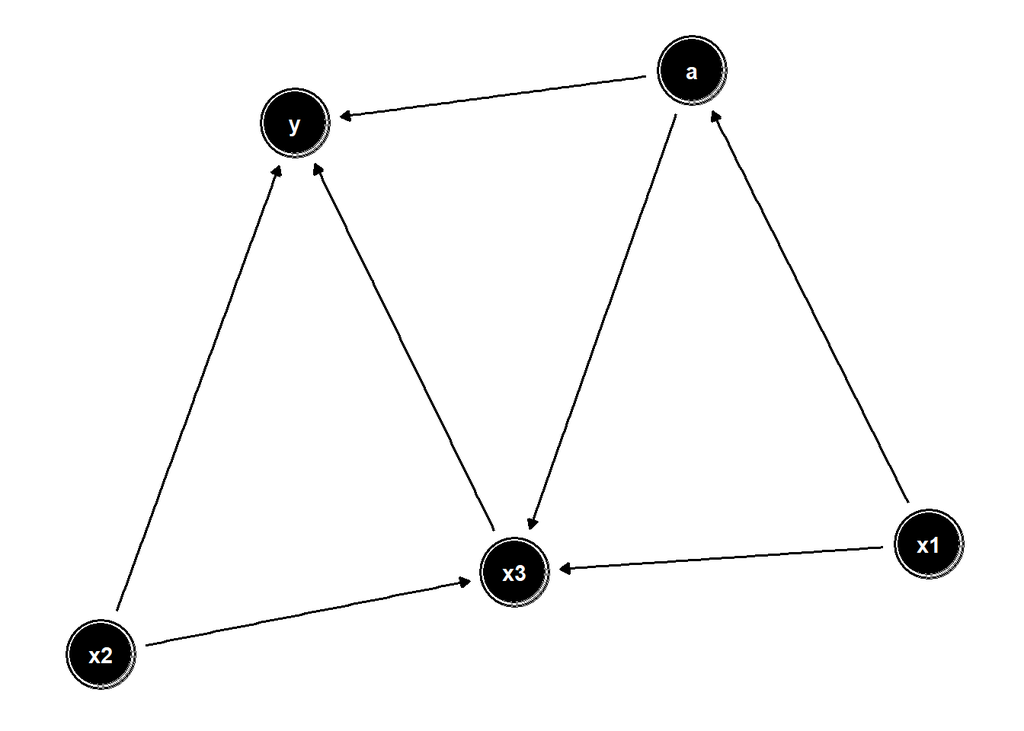

```r
dagified <- dagify(y ~ a,
                   y  ~ x2,
                   x3 ~ x2,
                   x3 ~ x1,
                   a ~ x1,
                   x3 ~ a,
                   y ~ x3,
                   exposure = "a",
                   outcome = "y")
dag <- tidy_dagitty(dagified)

ggdag(dag, layout = circle) +
  theme(panel.background = element_blank(), panel.grid.major = element_blank(), panel.grid.minor = element_blank())
```

#### Strategies

- Adjust for all pre-treatment variables
  - controlling for instruments can inflate standard errors
- Select minimum set using backdoor criterion
- Use disjunctive cause criterion
  - Requires knowing all vars that directly affect treatment decision and outcome
  - Just need to control for all potentially causal variables on both treatment and exposure
- Debate on data-driven approach
  - Could discard many weak confounders
  - inferential challenge about getting SEs right for data collection

## Identifiability and estimation

### Identification

Identifying assumptions

- Ignorability
  - If we condition on L, A tells us nothing about Y
- Positivity
- Consistency

#### Special case: standardization

E(*Y*<sup>a</sup>) = $\sum_{l = 0}^{1} f(x)$E(*Y*|*A* = *a*, *L*)*dF*(*L*)

#### Parametric G-Formula

Could estimate E(Y<sup>a</sup>) by using models for E(Y|A = a,L) and *f*(L)

E(*Y*<sup>*a*</sup>) = $\int_{}^{}$ E(*Y*|*A* = *a*,*L*;$\theta$)f(*L*;$\eta$)d*L*

#### Example

- Can fit logistic regression Y|A,L
- Get predicted values for Y for each L<sub>i</sub> if A set to a
- Average over empirical distribution of L
- do for *a* = 0 and *a* = 1

### Weighting

#### Standardization approach

Averaging over the marginal distributon of L

- downweights those exposed to L and upweights those not exposed to L

#### Propensity score

The propensity score is the conditional probability of treatment P(*A*|*L*)

IPTW

- Can weight by the inverse of the probability of treatment received
  - If P(A = 1|L) is high we expect that and we want that case to be weighted down
  - If P(A = 1|L) is low we don’t expect that and we want that case to be weighted up
- Creating a pseudo-population by getting rid of confounder by creating a balance between treated and controlled
- When we have balance we can just take sample means and have weighted estimates
- Basically “erasing an arrow” from confounding, but you have to get the right Ls to weight to

#### Stabilized weights

If the prob of a particular treatment give *L* is small, then the weight will be large, the use of stabilized weights can help

#### What we know about IPTW

- large weights lead to large SEs
- very large weights if positivity nearly violated
- We can do trimming or weight truncation to deal with large weights
- weight truncation is setting a max weight
- augmented IPTW - doubly robust and more efficient than IPTW

### Matching

Matching is an alternative to standardization and IPTW estimation

- Idea is to make the data more like what you would expect from a randomized trial
- Match treated subjects to controls subjects on the confounders
- Advtanges to matching
  - controlling for confounders is achieved at the design phase without looking at the outcome
  - Matching will reveal lack of overlap in covariate distribution
  - Once data are matched, essentiall treated as if from an RCT

#### Distance

- Matching requires calculating distance between L<sub>i</sub> and L<sub>j</sub>
  - can do this with exact matching
  - mahalanobis distance
  - mahalanobis distance with a caliper (if distance to large, we force it to not match)
  - propensity score - probability of treatment and compare scores for matching
  - propoensity score with caliper
- Can combine measures, such as using mahalanobis with propensity score caliper or KNN matching

#### Propensity score matching

- If there is poor overlap we’d have to do extrapolation. We’d lose lots of data if we did trimming.
- For subjects *i*,*j*, We then can create a distance matrix between e<sub>i</sub> and e<sub>j</sub> (propensity of *i* and *j*)

#### Criticisms

- Propensity is based on treatment so we might be overweighting a covariate highly related to *p* of treatment even though it might not be that related to outcome

#### Some match types

- Nearest Neighbor matching
  - Computationally fast but not optimal
- Optimal matching
  - Size of population limiting on ability to do optimal matching
- Sparse optimal matching
  - Somewhat stratified
  - Optimal matching within blocks
- After matching you can analyze outcome data

### R examples

#### Toy example

```r
library(sandwich)

n<-200
L<-rbinom(n,1,0.5)
A<-rbinom(n,1,(0.3+0.3*L))
Y<-rnorm(n,(35+10*L+20*A),5)
mydata<-data.frame(cbind(A,L,Y))

kable(head(mydata))
```

| A | L | Y |
| --- | --- | --- |
| 0 | 1 | 50.38451 |
| 0 | 1 | 41.17817 |
| 0 | 0 | 34.67657 |
| 1 | 1 | 71.61546 |
| 0 | 1 | 43.51090 |
| 1 | 0 | 50.45167 |

Let’s look at the diff of means

```r
#unadjusted
#mean of Y for treated subjects
mean(Y[A==1])
```

```
## [1] 60.74709
```

```r
#mean of Y for untreated subjects
mean(Y[A==0])
```

```
## [1] 37.85308
```

```r
#difference
mean(Y[A==1])-mean(Y[A==0])
```

```
## [1] 22.89401
```

##### We can fit a regression here.

```r
reg<-lm(Y~A+L,data=mydata)
summary(reg)
```

```
##
## Call:
## lm(formula = Y ~ A + L, data = mydata)
##
## Residuals:
##      Min       1Q   Median       3Q      Max
## -12.8535  -3.0404  -0.0125   3.4664  16.7057
##
## Coefficients:
##             Estimate Std. Error t value Pr(>|t|)
## (Intercept)  34.6593     0.5327   65.06   <2e-16 ***
## A            20.7418     0.7259   28.57   <2e-16 ***
## L             9.3293     0.7259   12.85   <2e-16 ***
## ---
## Signif. codes:  0 '***' 0.001 '**' 0.01 '*' 0.05 '.' 0.1 ' ' 1
##
## Residual standard error: 4.964 on 197 degrees of freedom
## Multiple R-squared:  0.8606, Adjusted R-squared:  0.8591
## F-statistic: 607.9 on 2 and 197 DF,  p-value: < 2.2e-16
```

##### Let’s compute standardization.

```r
#can do by hand since one binary covariate
pr.l <- prop.table(table(mydata$L))
kable(pr.l)
```

| Var1 | Freq |
| --- | --- |
| 0 | 0.555 |
| 1 | 0.445 |

```r
tab.out <- aggregate(Y ~ A + L, mydata, mean)
kable(tab.out)
```

| A | L | Y |
| --- | --- | --- |
| 0 | 0 | 34.78003 |
| 1 | 0 | 55.16908 |
| 0 | 1 | 43.75657 |
| 1 | 1 | 64.90325 |

##### Conditional means

We can computer conditional means and weigh by value of the covariate. This will allow us to correct the bias of treatment.

```r
((mean(mydata$Y[mydata$A==1 & mydata$L==1]) -
    mean(mydata$Y[mydata$A==0 & mydata$L==1]))*pr.l[2]) +
  (mean(mydata$Y[mydata$A==1 & mydata$L==0]) -
     mean(mydata$Y[mydata$A==0 & mydata$L==0]))*pr.l[1]
```

```
##       1
## 20.7262
```

##### We can also calculate propensity scores:

```r
p.score <- glm(A ~ as.factor(L), data=mydata, family=binomial)
p.a <- ifelse(mydata$A == 0, 1 - predict(p.score, type = "response"),
                  predict(p.score, type = "response"))
kable(table(p.a))
```

| p.a | Freq |
| --- | --- |
| 0.342342342342367 | 38 |
| 0.426966292134832 | 38 |
| 0.573033707865168 | 51 |
| 0.657657657657633 | 73 |

We get four values corresponding to two values of a for each treated and untreated L.

##### Next we can generate IP weights

```r
mydata$w <- 1/p.a
kable(table(mydata$w))
```

| Var1 | Freq |
| --- | --- |
| 1.52054794520554 | 73 |
| 1.74509803921569 | 51 |
| 2.34210526315789 | 38 |
| 2.92105263157874 | 38 |

```r
summary(mydata$w)
```

```
##    Min. 1st Qu.  Median    Mean 3rd Qu.    Max.
##   1.521   1.521   1.745   2.000   2.342   2.921
```

```r
sd(mydata$w)
```

```
## [1] 0.5341539
```

##### Let’s estimate ATE

```r
mean(mydata$w*as.numeric(mydata$A==1)*mydata$Y) -
  mean(mydata$w*as.numeric(mydata$A==0)*mydata$Y)
```

```
## [1] 20.7262
```

##### Creating a marginal structural model

```r
msm <- lm(Y  ~ A, data = mydata, weights = w)
```

##### Now with inference

Weights create a pseudo population:

```r
SE <-sqrt(diag(vcovHC(msm, type="HC0"))) # robust standard errors
beta <- coef(msm)
lcl <- beta-1.96*SE
ucl <- beta+1.96*SE
cbind(beta, lcl, ucl)[2,]
```

```
##     beta      lcl      ucl
## 20.72620 18.78508 22.66732
```

#### Real data

##### Let’s load our data:

```r
library(tableone)
library(Matching)
library(geepack)
library(stats)


load(url("https://urldefense.proofpoint.com/v2/url?u=http-3A__biostat.mc.vanderbilt.edu_wiki_pub_Main_DataSets_rhc.sav&d=DwIGAg&c=lEzKI_JJakPtcnbAQ6Q5xQ&r=ADBnQF_uxktNSAkWyomgLeFb-eOkP5LRzvDAXj-4ESQ&m=GJ1JdJTpKzJvLWlb0bGX87lB6Gx5rPtIV9m0KvRo6AI&s=639__Kuc3BOyiS-CFnTwBH3AVQyrBK3GMJStuyusjrk&e="))

kable(head(rhc))
```

| cat1 | cat2 | ca | sadmdte | dschdte | dthdte | lstctdte | death | cardiohx | chfhx | dementhx | psychhx | chrpulhx | renalhx | liverhx | gibledhx | malighx | immunhx | transhx | amihx | age | sex | edu | surv2md1 | das2d3pc | t3d30 | dth30 | aps1 | scoma1 | meanbp1 | … |
| --- | --- | --- | --- | --- | --- | --- | --- | --- | --- | --- | --- | --- | --- | --- | --- | --- | --- | --- | --- | --- | --- | --- | --- | --- | --- | --- | --- | --- | --- | --- |
| COPD | NA | Yes | 11142 | 11151 | NA | 11382 | No | 0 | 0 | 0 | 0 | 1 | 0 | 0 | 0 | 1 | 0 | 0 | 0 | 70.25098 | Male | 12.000000 | 0.6409912 | 23.50000 | 30 | No | 46 | 0 | 41 | … |
| MOSF w/Sepsis | NA | No | 11799 | 11844 | 11844 | 11844 | Yes | 1 | 1 | 0 | 0 | 0 | 0 | 0 | 0 | 0 | 1 | 1 | 0 | 78.17896 | Female | 12.000000 | 0.7549996 | 14.75195 | 30 | No | 50 | 0 | 63 | … |
| MOSF w/Malignancy | MOSF w/Sepsis | Yes | 12083 | 12143 | NA | 12400 | No | 0 | 0 | 0 | 0 | 0 | 0 | 0 | 0 | 1 | 1 | 0 | 0 | 46.09198 | Female | 14.069916 | 0.3169999 | 18.13672 | 30 | No | 82 | 0 | 57 | … |
| ARF | NA | No | 11146 | 11183 | 11183 | 11182 | Yes | 0 | 0 | 0 | 0 | 0 | 0 | 0 | 0 | 0 | 1 | 0 | 0 | 75.33197 | Female | 9.000000 | 0.4409790 | 22.92969 | 30 | No | 48 | 0 | 55 | … |
| MOSF w/Sepsis | NA | No | 12035 | 12037 | 12037 | 12036 | Yes | 0 | 0 | 0 | 0 | 0 | 0 | 0 | 0 | 0 | 0 | 0 | 0 | 67.90997 | Male | 9.945259 | 0.4369998 | 21.05078 | 2 | Yes | 72 | 41 | 65 | … |
| COPD | NA | No | 12389 | 12396 | NA | 12590 | No | 0 | 1 | 0 | 0 | 1 | 0 | 0 | 0 | 0 | 0 | 0 | 0 | 86.07794 | Female | 8.000000 | 0.6650000 | 17.50000 | 30 | No | 38 | 0 | 115 | … |

##### Then we create binaries out of cat1 and make a new dataset:

```r
ARF<-as.numeric(rhc$cat1=='ARF')
CHF<-as.numeric(rhc$cat1=='CHF')
Cirr<-as.numeric(rhc$cat1=='Cirrhosis')
colcan<-as.numeric(rhc$cat1=='Colon Cancer')
Coma<-as.numeric(rhc$cat1=='Coma')
COPD<-as.numeric(rhc$cat1=='COPD')
lungcan<-as.numeric(rhc$cat1=='Lung Cancer')
MOSF<-as.numeric(rhc$cat1=='MOSF w/Malignancy')
sepsis<-as.numeric(rhc$cat1=='MOSF w/Sepsis')
female<-as.numeric(rhc$sex=='Female')
died<-as.numeric(rhc$death=='Yes')
age<-rhc$age
treatment<-as.numeric(rhc$swang1=='RHC')
meanbp1<-rhc$meanbp1


mydata <-data.frame(cbind(ARF,CHF,Cirr,colcan,Coma,lungcan,MOSF,sepsis,
              age,female,meanbp1,treatment,died))

kable(head(mydata))
```

| ARF | CHF | Cirr | colcan | Coma | lungcan | MOSF | sepsis | age | female | meanbp1 | treatment | died |
| --- | --- | --- | --- | --- | --- | --- | --- | --- | --- | --- | --- | --- |
| 0 | 0 | 0 | 0 | 0 | 0 | 0 | 0 | 70.25098 | 0 | 41 | 0 | 0 |
| 0 | 0 | 0 | 0 | 0 | 0 | 0 | 1 | 78.17896 | 1 | 63 | 1 | 1 |
| 0 | 0 | 0 | 0 | 0 | 0 | 1 | 0 | 46.09198 | 1 | 57 | 1 | 0 |
| 1 | 0 | 0 | 0 | 0 | 0 | 0 | 0 | 75.33197 | 1 | 55 | 0 | 1 |
| 0 | 0 | 0 | 0 | 0 | 0 | 0 | 1 | 67.90997 | 0 | 65 | 1 | 1 |
| 0 | 0 | 0 | 0 | 0 | 0 | 0 | 0 | 86.07794 | 1 | 115 | 0 | 0 |

##### Making a vector out of covariates and printing summary results

```r
xvars<-c("ARF","CHF","Cirr","colcan","Coma","lungcan","MOSF","sepsis",
         "age","female","meanbp1")
table1<- CreateTableOne(vars=xvars,strata="treatment", data=mydata, test=FALSE)

print(table1,smd=TRUE)
```

```
##                      Stratified by treatment
##                       0             1             SMD
##   n                    3551          2184
##   ARF (mean (SD))      0.45 (0.50)   0.42 (0.49)   0.059
##   CHF (mean (SD))      0.07 (0.25)   0.10 (0.29)   0.095
##   Cirr (mean (SD))     0.05 (0.22)   0.02 (0.15)   0.145
##   colcan (mean (SD))   0.00 (0.04)   0.00 (0.02)   0.038
##   Coma (mean (SD))     0.10 (0.29)   0.04 (0.20)   0.207
##   lungcan (mean (SD))  0.01 (0.10)   0.00 (0.05)   0.095
##   MOSF (mean (SD))     0.07 (0.25)   0.07 (0.26)   0.018
##   sepsis (mean (SD))   0.15 (0.36)   0.32 (0.47)   0.415
##   age (mean (SD))     61.76 (17.29) 60.75 (15.63)  0.061
##   female (mean (SD))   0.46 (0.50)   0.41 (0.49)   0.093
##   meanbp1 (mean (SD)) 84.87 (38.87) 68.20 (34.24)  0.455
```

##### Print unadjusted mean diffs

```r
mean(died[treatment==1])
```

```
## [1] 0.6804029
```

```r
mean(died[treatment==0])
```

```
## [1] 0.6296818
```

##### Create an outmodel

```r
outmodel<-glm(died~treatment+ARF+CHF+Cirr+colcan+Coma+lungcan+MOSF+
               sepsis+age+female+meanbp1,
             family=binomial(),data=mydata)
```

##### Can create predicted values for each person if and if not treated

```r
#now get predicted values for each person if they had been treated
mydata1<-mydata
mydata1$treatment<-1
pred1<-predict(outmodel,mydata1,type='response')

#get predicted values for each person if they had not been treated
mydata0<-mydata
mydata0$treatment<-0
pred0<-predict(outmodel,mydata0,type='response')

mean(pred1)
```

```
## [1] 0.6797657
```

```r
mean(pred0)
```

```
## [1] 0.6298412
```

##### Propensity Scores

```r
psmodel<-glm(treatment~ARF+CHF+Cirr+colcan+Coma+lungcan+MOSF+
               sepsis+age+female+meanbp1,
             family=binomial(),data=mydata)

#show coefficients etc
summary(psmodel)
```

```
##
## Call:
## glm(formula = treatment ~ ARF + CHF + Cirr + colcan + Coma +
##     lungcan + MOSF + sepsis + age + female + meanbp1, family = binomial(),
##     data = mydata)
##
## Deviance Residuals:
##     Min       1Q   Median       3Q      Max
## -1.7013  -1.0097  -0.6336   1.1814   2.4791
##
## Coefficients:
##               Estimate Std. Error z value Pr(>|z|)
## (Intercept) -0.7299670  0.1997692  -3.654 0.000258 ***
## ARF          1.2931956  0.1487784   8.692  < 2e-16 ***
## CHF          1.6804704  0.1715672   9.795  < 2e-16 ***
## Cirr         0.5234506  0.2181458   2.400 0.016416 *
## colcan       0.0295468  1.0985361   0.027 0.978542
## Coma         0.7013451  0.1854937   3.781 0.000156 ***
## lungcan     -0.0869570  0.5039331  -0.173 0.863000
## MOSF         1.3046587  0.1772705   7.360 1.84e-13 ***
## sepsis       2.0433604  0.1545437  13.222  < 2e-16 ***
## age         -0.0031374  0.0017289  -1.815 0.069567 .
## female      -0.1697903  0.0583574  -2.909 0.003620 **
## meanbp1     -0.0109824  0.0008217 -13.366  < 2e-16 ***
## ---
## Signif. codes:  0 '***' 0.001 '**' 0.01 '*' 0.05 '.' 0.1 ' ' 1
##
## (Dispersion parameter for binomial family taken to be 1)
##
##     Null deviance: 7621.4  on 5734  degrees of freedom
## Residual deviance: 6983.6  on 5723  degrees of freedom
## AIC: 7007.6
##
## Number of Fisher Scoring iterations: 4
```

```r
#create propensity score
pscore<-psmodel$fitted.values
```

##### Create weights from pscore

We can output quick histograms to make sure there is enough overlap.

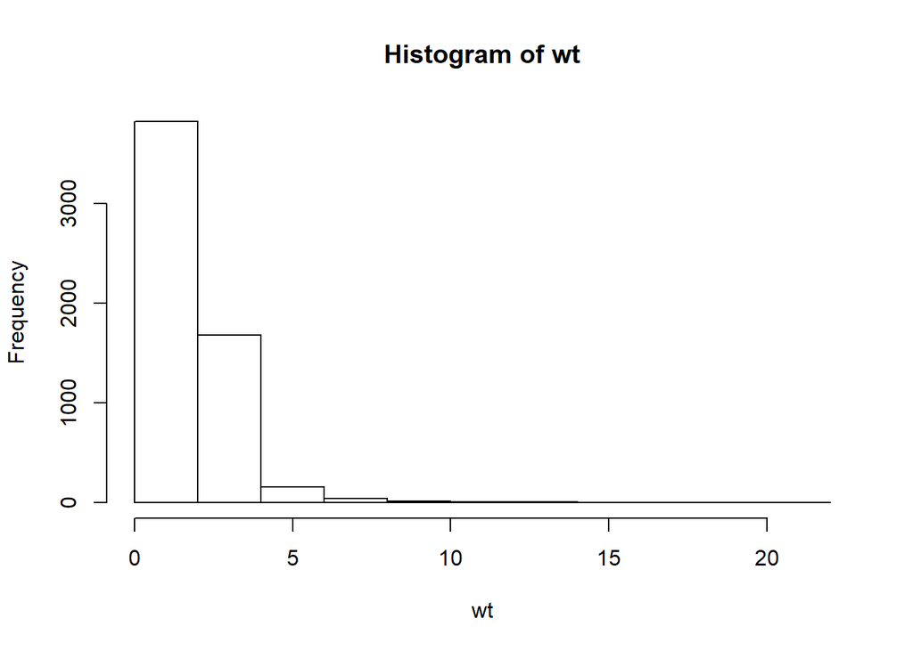

```r
#unstabilized weights
wt<-ifelse(treatment==1,1/pscore,1/(1-pscore))
hist(wt)
```

```r
summary(wt)
```

```
##    Min. 1st Qu.  Median    Mean 3rd Qu.    Max.
##   1.046   1.405   1.721   2.001   2.280  21.606
```

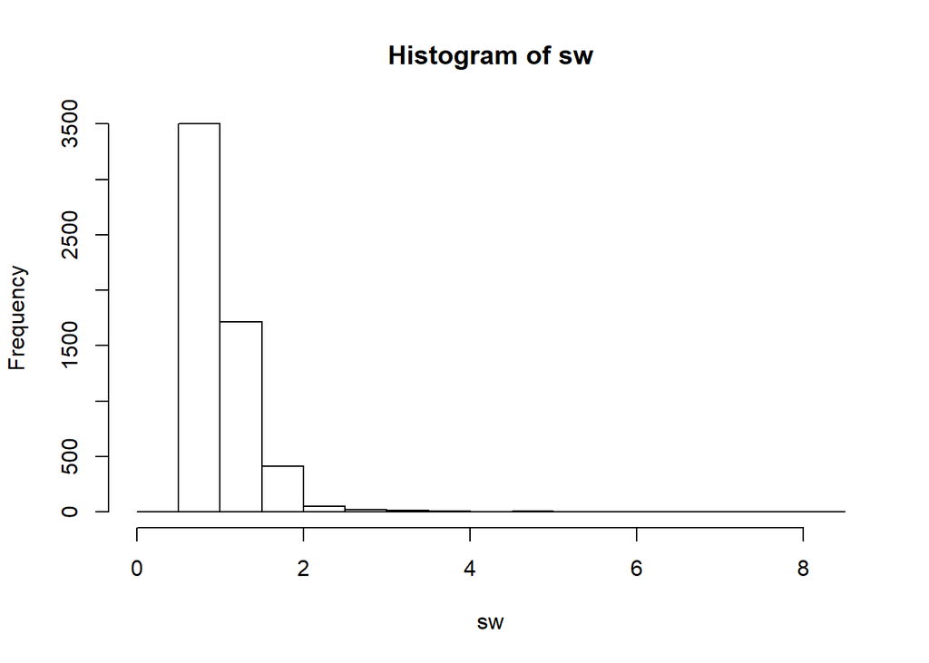

```r
#stabilized weights
#probability of treatment (unconditional)
probt<-mean(treatment)
sw<-ifelse(treatment==1,probt/pscore,(1-probt)/(1-pscore))
hist(sw)
```

```r
summary(sw)
```

```
##    Min. 1st Qu.  Median    Mean 3rd Qu.    Max.
##  0.4917  0.7579  0.8990  1.0004  1.0997  8.2279
```

##### Do a weighted regression

```r
weighted.mean(died[treatment==1],wt[treatment==1])
```

```
## [1] 0.6820133
```

```r
weighted.mean(died[treatment==0],wt[treatment==0])
```

```
## [1] 0.6304638
```

```r
#now do weighted regression (get same estimates)
id<-1:length(died)
msm1 <- geeglm(as.numeric(died) ~ treatment,
               id = id,
               weights = wt,
               family = binomial(link=logit))
summary(msm1)
```

```
##
## Call:
## geeglm(formula = as.numeric(died) ~ treatment, family = binomial(link = logit),
##     weights = wt, id = id)
##
##  Coefficients:
##             Estimate Std.err   Wald Pr(>|W|)
## (Intercept)  0.53421 0.03602 219.95  < 2e-16 ***
## treatment    0.22883 0.06486  12.45 0.000419 ***
## ---
## Signif. codes:  0 '***' 0.001 '**' 0.01 '*' 0.05 '.' 0.1 ' ' 1
##
## Estimated Scale Parameters:
##             Estimate Std.err
## (Intercept)        1 0.01235
##
## Correlation: Structure = independenceNumber of clusters:   5735   Maximum cluster size: 1
```

```r
head(msm1$fitted.values)
```

```
##     [,1]
## 1 0.6305
## 2 0.6820
## 3 0.6820
## 4 0.6305
## 5 0.6820
## 6 0.6305
```

```r
#using stabilized weights
msm2 <- geeglm(as.numeric(died) ~ treatment,
               id = id,
               weights = sw,
               data=mydata,
               family = binomial(link=logit))
summary(msm2)
```

```
##
## Call:
## geeglm(formula = as.numeric(died) ~ treatment, family = binomial(link = logit),
##     data = mydata, weights = sw, id = id)
##
##  Coefficients:
##             Estimate Std.err  Wald Pr(>|W|)
## (Intercept)   0.5342  0.0360 219.9  < 2e-16 ***
## treatment     0.2288  0.0649  12.4  0.00042 ***
## ---
## Signif. codes:  0 '***' 0.001 '**' 0.01 '*' 0.05 '.' 0.1 ' ' 1
##
## Estimated Scale Parameters:
##             Estimate Std.err
## (Intercept)        1  0.0106
##
## Correlation: Structure = independenceNumber of clusters:   5735   Maximum cluster size: 1
```

```r
head(msm2$fitted.values)
```

```
##    [,1]
## 1 0.630
## 2 0.682
## 3 0.682
## 4 0.630
## 5 0.682
## 6 0.630
```

#### Matching example

```r
greedymatch<-Match(Tr=treatment,M=1,X=mydata[xvars],replace=FALSE)
matched<-mydata[unlist(greedymatch[c("index.treated","index.control")]), ]

#get table 1 for matched data with standardized differences
matchedtab1<-CreateTableOne(vars=xvars, strata ="treatment",
                            data=matched, test = FALSE)
print(matchedtab1, smd = TRUE)
```

```
##                      Stratified by treatment
##                       0             1             SMD
##   n                    2184          2184
##   ARF (mean (SD))      0.42 (0.49)   0.42 (0.49)   0.006
##   CHF (mean (SD))      0.10 (0.29)   0.10 (0.29)  <0.001
##   Cirr (mean (SD))     0.02 (0.15)   0.02 (0.15)  <0.001
##   colcan (mean (SD))   0.00 (0.02)   0.00 (0.02)  <0.001
##   Coma (mean (SD))     0.04 (0.20)   0.04 (0.20)  <0.001
##   lungcan (mean (SD))  0.00 (0.05)   0.00 (0.05)  <0.001
##   MOSF (mean (SD))     0.07 (0.26)   0.07 (0.26)  <0.001
##   sepsis (mean (SD))   0.24 (0.43)   0.32 (0.47)   0.177
##   age (mean (SD))     61.53 (16.15) 60.75 (15.63)  0.049
##   female (mean (SD))   0.44 (0.50)   0.41 (0.49)   0.042
##   meanbp1 (mean (SD)) 73.12 (34.28) 68.20 (34.24)  0.144
```

```r
#outcome analysis
y_trt<-matched$died[matched$treatment==1]
y_con<-matched$died[matched$treatment==0]
mean(y_trt)
```

```
## [1] 0.68
```

```r
mean(y_con)
```

```
## [1] 0.626
```

```r
#pairwise difference
diffy<-y_trt-y_con

#paired t-test
t.test(diffy)
```

```
##
##  One Sample t-test
##
## data:  diffy
## t = 4, df = 2000, p-value = 9e-05
## alternative hypothesis: true mean is not equal to 0
## 95 percent confidence interval:
##  0.0271 0.0810
## sample estimates:
## mean of x
##     0.054
```

```r
#McNemar test
kable(table(y_trt,y_con))
```

|  | 0 | 1 |
| --- | --- | --- |
| 0 | 303 | 395 |
| 1 | 513 | 973 |

```r
mcnemar.test(matrix(c(973,513,395,303),2,2))
```

```
##
##  McNemar's Chi-squared test with continuity correction
##
## data:  matrix(c(973, 513, 395, 303), 2, 2)
## McNemar's chi-squared = 20, df = 1, p-value = 1e-04
```

## Causal Mediation

This is a case where we have an intervening variable that affects outcome, but isn’t confounding.

### Direct and indirect effects

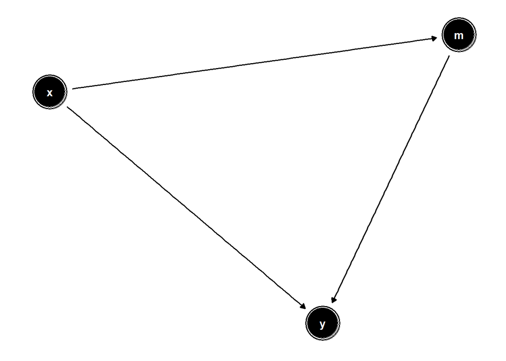

```r
dag3 <- dagify(y ~ x,
       y ~ x + m,
       m ~ x)
dag_med <- tidy_dagitty(dag3)

ggdag(dag_med, layout = circle) +
  theme(panel.background = element_blank(), panel.grid.major = element_blank(), panel.grid.minor = element_blank())
```

Traditional approach is to fit two regression models (Baron and Kenny)

#### Controlled direct effects

- Setting treatment to *a* but for mediator values we set values to Y<sup>A,MA</sup>

#### Natural direct effects

- setting treatment a to a then comparing the potential outcomes if mediator was set to what it would be if treatment a versus if treatment 0

#### Cross-world conterfactual

- unobservable usually
- Integrating over a different distribution
  - Average mediator distribution over non treated